# EJERCICIO FINAL

Esther Gabay

2019-11-27

## Expresiones Regulares

Al realizar una amplia investigación sobre determinadas páginas webs y videosdonde hubiesen recursos de expresiones regulares útiles y fáciles de usar, he elegidolos siguientes: Ejemplo [A](https://stringr.tidyverse.org/articles/regular-expressions.html) He destacado este ejemplo como bueno, por lo practico y sencillo que es a la hora de usar la web como herramienta de trabajo, sobre todo para aquellos que no están muy familiarizados con las expresiones regulares.También, por los comentarios, que te explican cada codigo,ejemplos de como se haría según la función que necesitemos en cada momento,así como las excepciones que se pueden ocasionar en cada caso. Dentro de la misma web también hay otras opciones de interés como son noticias y nuevas versiones, y para los que no son amigos de r aún hay una pestaña que te dice por dónde empezar y cómo.

En cuanto al ejemplo [B](http://www.endmemo.com/program/R/gsub.php) que elegido usado para contrastar y que hemos asignado como el malo por darle un nombre, podemos destacar que solo tiene una función y algo de sintásis que te explica pero muy reducido.También señalamos que hay tutoriales a la derecha pero son de otros lenguajes de programación,aunque junto a estos hay varias funciones que cuando hacer link a la pagina te lleva a otra web donde te explica de forma similar a lo anterior como aplicar esa función.

Como conclusión, asignamos la url [A](https://stringr.tidyverse.org/articles/regular-expressions.html) como la más intuitiva de usar, práctica y útil a la hora de tener una herramienta de expresiones regulares que usar para trabajar.

## R Markdown

A la hora de buscar una herramienta de trabajo sobre markdown, hemos llegado a la conclusión de que: Opción [C](https://rmarkdown.rstudio.com/lesson-9.html) es mejor que opción [D](https://www.maximaformacion.es/blog-dat/rmarkdown-para-principiantes/) porque según el proyecto en el que estes trabajando, puedes irte al menu y mirar qué es lo que buscas y dónde esta la solución a tu pregunta, por lo que me parece la web más completa de todas las que he investigado.Además, en la url [C](https://rmarkdown.rstudio.com/lesson-9.html) te indica paso a paso desde introducirte markdown hasta mapas interactivos, cada pestaña bien explicada con su ejemplo, para saber como aplicarlo luego en r.Sin embargo, la opción [D](https://www.maximaformacion.es/blog-dat/rmarkdown-para-principiantes/) al ser un video tutorial, está más enfocado a principiantes que quieran seguir un curso de rmarkdown que a tenerlo como herramienta de trabajo, por el simple hecho de que si cada vez que necesitamos hacer una consulta tenemos que ir a ver el video, entonces perdemos mucho tiempo en una simple cuestión.

Como conclusión, elegimos la opción [C](https://rmarkdown.rstudio.com/lesson-9.html) por la variedad de opciones que tiene a la hora de encontrar las funciones necesarias en el trabajo que estemos realizando.

## Gráficos - Tablas - Comentarios

Antes de empezar hablar de gráficos y tablas, vamos a explicar que es dow jones, pues bien es un indice bursatil que fue creado por un periodista de Wall Street en el que se mide el desempeño de las treinta mayores sociedades anónimas que cotizan en el mercado bursátil de Estados Unidos.Este indice se calcula dividiendo el valor total de las acciones por número de estas.Sin embargo, para compensar los efectos del desdoblamiento de acciones que se da cuando una empresa aumenta las acciones manteniendo el valor de su capitalización de mercado,dando lugar a un número de acciones mayor con un valor menor cada una, el valor total pasó a dividirse por una fórmula matemática que da mayor peso a la empresas grandes.A causa de ellos,y un ejemplo es que los títulos de Microsoft tienen más peso que las acciones de una empresa con una capitalización pequeña.A continuación, vamos a explicar la tabla que podemos con algunas de las empresas y con su valor de cotización en el día 17/11/2019.

### Tabla

| Nombre | Último | Diferencia | Diferencia porcentual | Volumen | Hora |
| --- | --- | --- | --- | --- | --- |
| 3M COMPANY | 169.23 | -1,01 | -0,59 | 2613188 | 22:52 |
| AMER.EXPRESS | 119.79 | -0,81 | -0,67 | 4596905 | 22:52 |
| APPLE INC | 264.29 | -2,08 | -0,78 | 26334882 | 23:59 |
| BOEING CO. | 373.51 | 0,38 | 0,10 | 2840346 | 22:52 |
| CATERPILLAR | 146.09 | -0,33 | -0,23 | 2468450 | 22:52 |
| CHEVRON CORP | 117.79 | -0,59 | -0,50 | 9468533 | 22:59 |

### Gráfico de puntos y dinámico

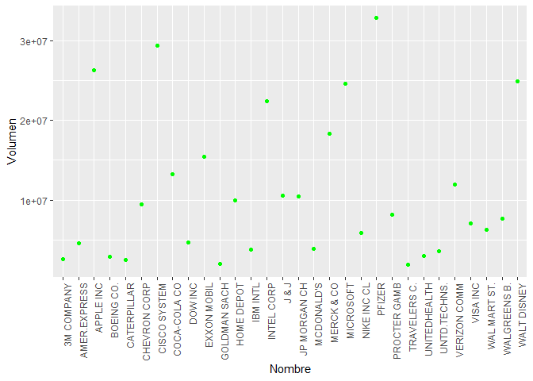

En el gráfico de puntos verdes tenemos todas las empresas con su volumen de acciones el día diecisiete de noviembre.Según este gráfico, podemos destacar las tres empresas americanas que mayor volumen de acciones presentan que son en orden de mayor a menor:Pfizer, seguida de cisco System y por último Apple. En cuanto a las tres compañias americanas que menor volumen presentan en el gráfico tenemos de menor a mayor:Travelers, Goldman y Cater Pilar.No hemos podido hallar una línea dentro del gráfico de puntos debido a que los desniveles entre una empresa y otra son bastantes.

[interactive chart not shown]